# STAT 486/586

### Random draws

To obtain random draws from a binomial use the `rbinom` function.

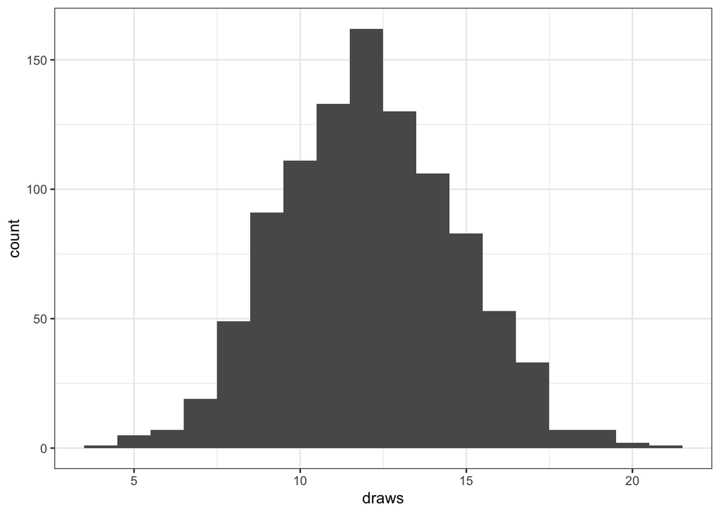

```r
draws <- rbinom(1000, size = n, prob = p)

ggplot(mapping = aes(x = draws)) +
  geom_histogram(binwidth = 1)
```

Let’s compare our empirical probabilities to the true probabilities.

```r
mean(10 < draws & draws < 14) # vs
```

```
## [1] 0.425
```

```r
pbinom(13, size = n, prob = p) -
  pbinom(10, size = n, prob = p)
```

```
## [1] 0.4230325
```

## Poisson

### Probability mass function

A random variable has a Poisson distribution it its probability mass function is
$$P(Y=y) = \frac{e^{-r}r^y}{y!}$$
for some rate $r>0$ and integer $y\ge 0$.

We use `dpois` for the Poisson pmf.

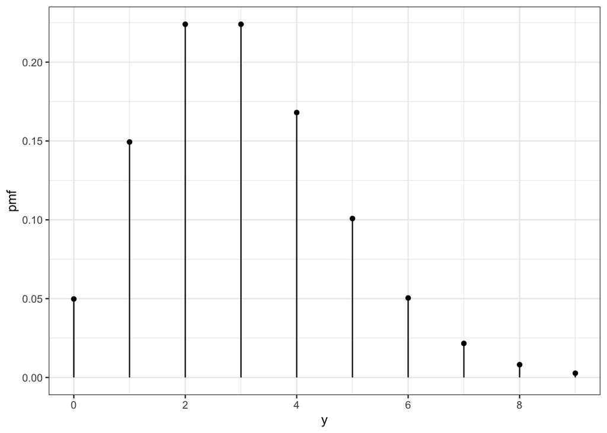

```r
r <- 3
d <- data.frame(y = 0:(3*r)) %>%
  mutate(pmf = dpois(y, lambda = r),
         cdf = ppois(y, lambda = r))

ggplot(d, aes(x = y, y = pmf, xend = y, yend = 0)) +
  geom_point() +
  geom_segment() +
  scale_x_continuous(breaks = breaks_pretty())
```

### Cumulative distribution function

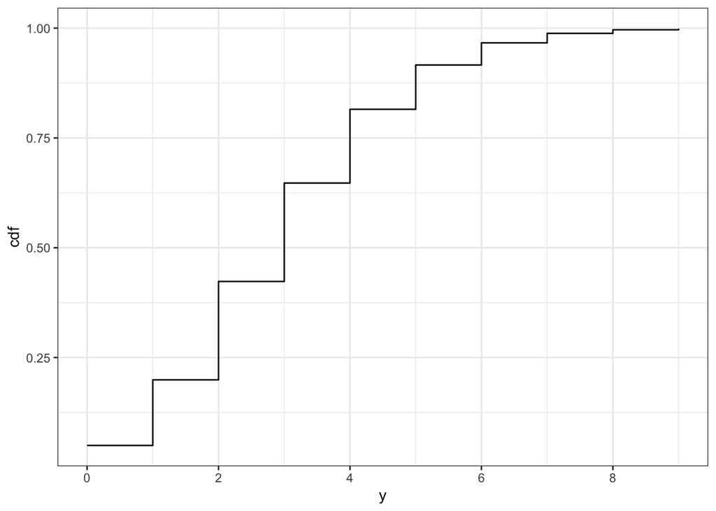

```r
ggplot(d, aes(x = y, y = cdf)) +
  geom_step() +
  scale_x_continuous(breaks = breaks_pretty())
```

### Random draws

To obtain random draws from a Poisson distribution use `rpois`.

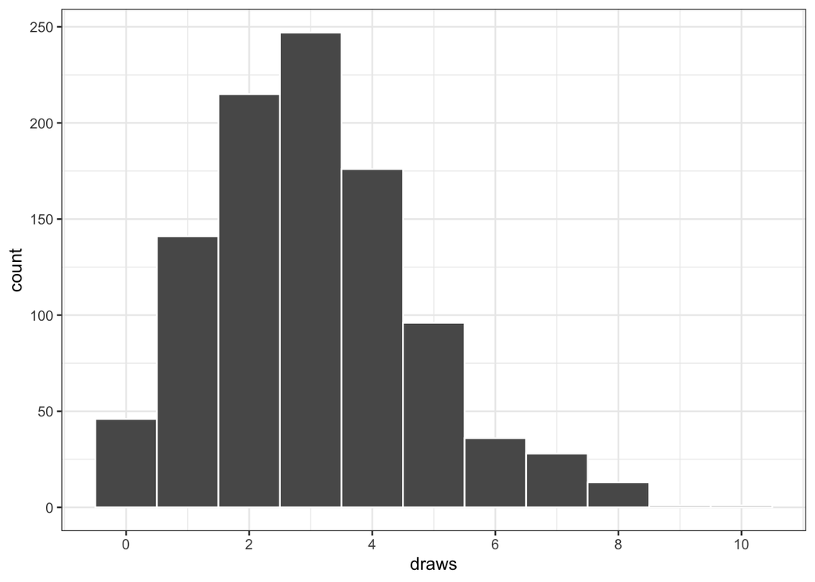

```r
draws <- rpois(1000, lambda = r)

ggplot(mapping = aes(x = draws)) +
  geom_histogram(binwidth = 1, color = "white") +
  scale_x_continuous(breaks = breaks_pretty())
```

# Continuous distributions

## Normal (Gaussian)

### Probability density function

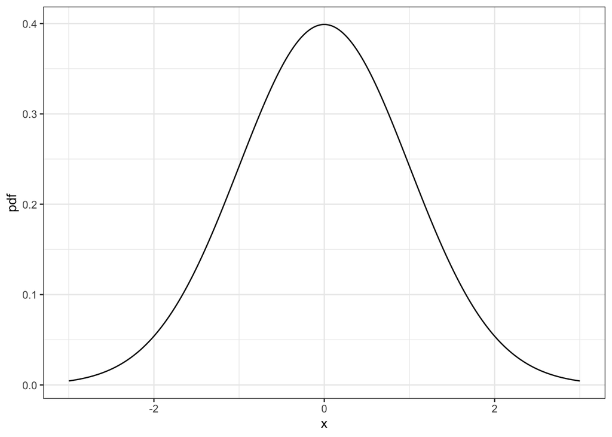

```r
m <- 0
s <- 1 # standard deviation

d <- data.frame(x = seq(m - 3*s, m + 3*s, length = 1001)) %>%
  mutate(pdf = dnorm(x, m, s),
         cdf = pnorm(x, m, s))

ggplot(d, aes(x = x, y = pdf)) +
  geom_line()
```

### Cumulative distribution function

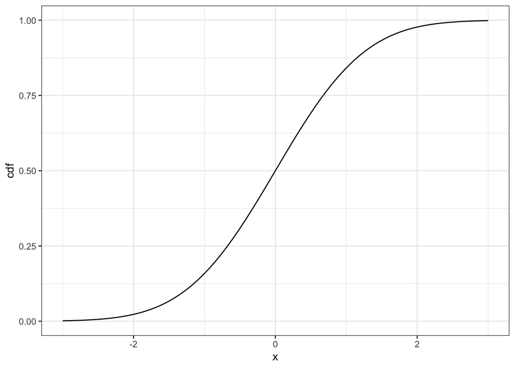

```r
ggplot(d, aes(x = x, y = cdf)) +
  geom_line()
```

### Critical values

The `qnorm` function provides the inverse of the normal CDF. We can plot this function

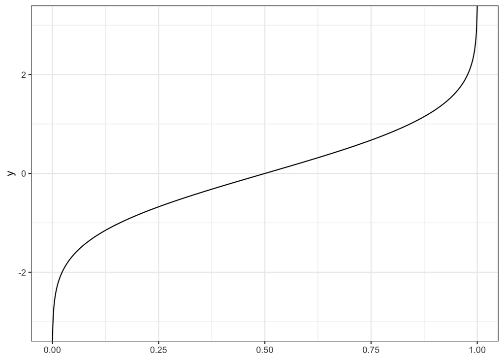

```r
ggplot(data.frame(p = 0:1)) +
  stat_function(fun = qnorm, n = 1001, args = list(mean = m, sd = s))
```

The most common use of this function is to obtain z critical values for us in constructing confidence intervals.

```r
qnorm(.975)
```

```
## [1] 1.959964
```

### Random draws

We can use the `rnorm` function to sample random draws from the normal distribution.

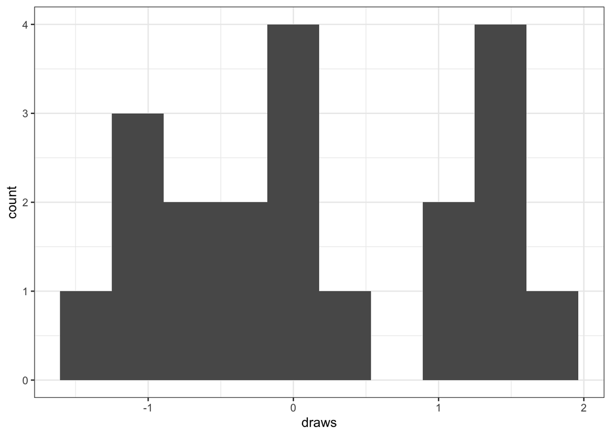

```r
draws <- rnorm(20)

ggplot() +
  geom_histogram(mapping = aes(x = draws), bins = 10)
```

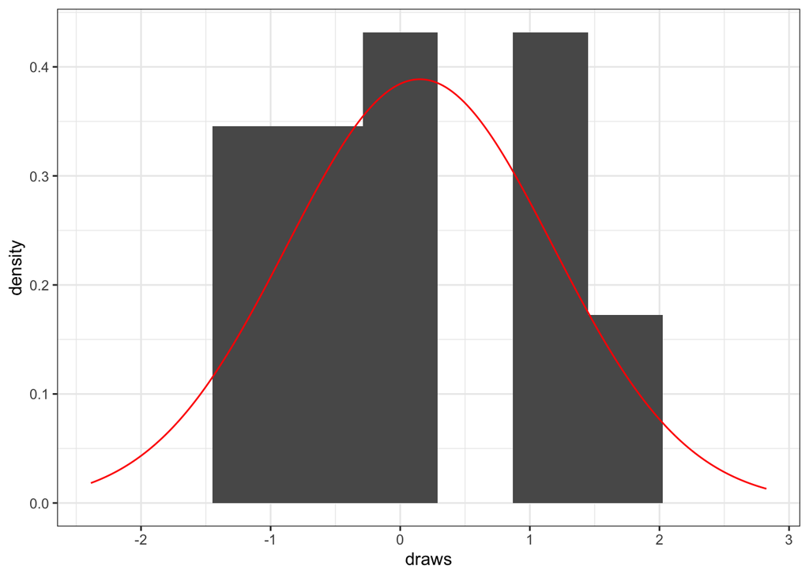

```r
ggplot() +
  geom_histogram(
    mapping = aes(
      x = draws,
      y = after_stat(density)),
    bins = 10) +
  stat_function(fun = dnorm,
                n = 1001,
                args = list(
                  mean = mean(draws),
                  sd = sd(draws)),
                color = 'red') +
  xlim(min(draws)-1, max(draws) + 1)
```

If we have a much larger sample size, the histogram will look approximately normal.

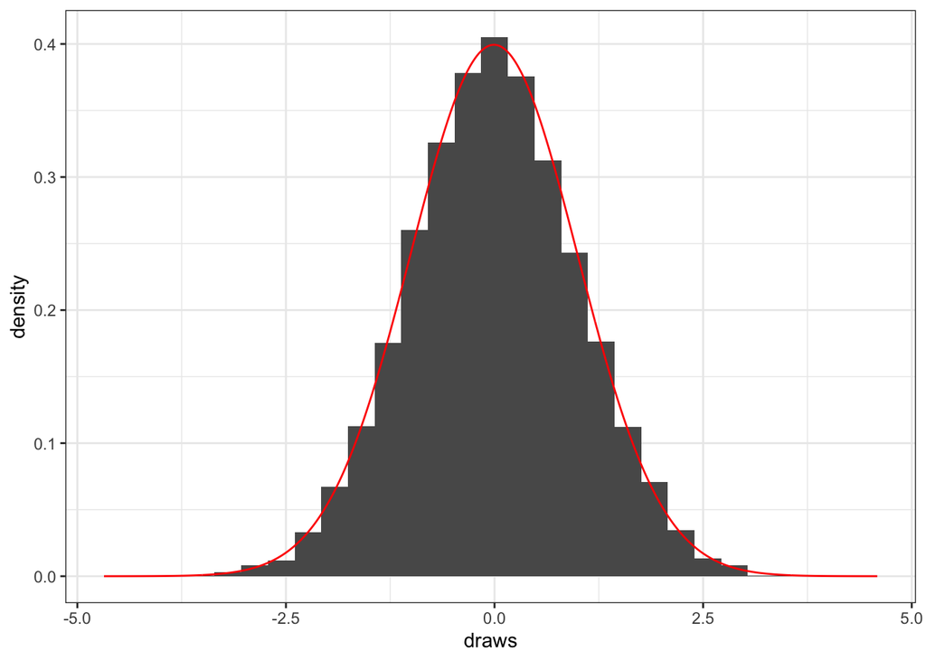

```r
draws <- rnorm(1e4)

ggplot() +
  geom_histogram(
    mapping = aes(
      x = draws,
      y = after_stat(density)),
    bins = 30) +
  stat_function(fun = dnorm,
                n = 1001,
                args = list(
                  mean = mean(draws),
                  sd = sd(draws)),
                color = 'red') +
  xlim(min(draws)-1, max(draws) + 1)
```

## Student’s t

### Probability density function

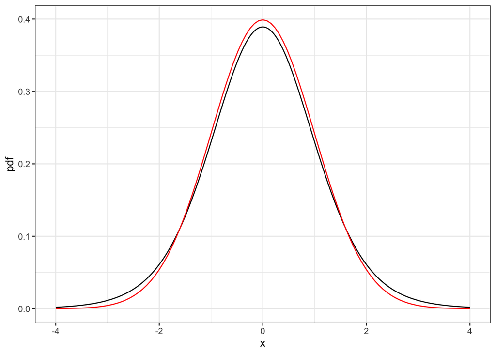

```r
df <- 10

d <- data.frame(x = seq(-4, 4, length = 1001)) %>%
  mutate(pdf = dt(x, df = df),
         cdf = pt(x, df = df))

ggplot(d, aes(x = x, y = pdf)) +
  geom_line() +
  stat_function(fun = dnorm, color = 'red')
```

### Calculative p-values

Suppose you have the following data

```r
y <- round(rnorm(10), 2)
y
```

```
##  [1] -1.32  0.46 -1.66 -1.10 -0.43  0.37  1.88 -0.65  0.87 -0.52
```

Which has the following summary statistics

```r
n <- length(y); n
```

```
## [1] 10
```

```r
m <- mean(y); m
```

```
## [1] -0.21
```

```r
s <- sd(y); s
```

```
## [1] 1.094664
```

If you are interested in the following hypothesis test:
$$H_0: \mu=1 \quad \mbox{vs} \quad H_A: \mu \ne 1$$
then the test statistic is

```r
t <- (m-1)/(s/sqrt(n)); t
```

```
## [1] -3.495462
```

Under the null hypothesis, this statistic has a $t$ distribution with $n-1$ degrees of freedom. We can then compute the p-value using

```r
pvalue <- 2*pt(-abs(t), df = n-1); pvalue
```

```
## [1] 0.006771688
```

Of course, we could use the built-in functions in R

```r
t.test(y, mu = 1)$p.value
```

```
## [1] 0.006771688
```

### Critical values

The main use of the quantile function (or inverse CDF) is to compute t critical values. For example,

```r
tcrit <- qt(.95, df = n-1); tcrit
```

```
## [1] 1.833113
```

So a 90% CI for the mean is

```r
m + c(-1,1)*tcrit*s/sqrt(n)
```

```
## [1] -0.844556  0.424556
```

Of course, we could just use built-in functions

```r
t.test(y, conf.level = 0.9)$conf.int
```

```
## [1] -0.844556  0.424556
## attr(,"conf.level")
## [1] 0.9
```